# Chapter 7: Unraveling Transcriptomic Complexity with Weighted Gene Co-expression Network Analysis (WGCNA)

## Expanding Beyond Transcriptomics: WGCNA for Proteomics Data

WGCNA’s principles can be applied to other high-dimensional data, like proteomics from platforms such as Olink. The workflow remains largely the same, using protein abundance levels as input.

Example R Workflow for Olink Proteomics Data

```r
# We will simulate Olink-style data for this example
# In a real scenario, you would load your data:
# lnames = load(file = "OlinkProteomics-Input.RData");

# Simulate protein data
nProteins = 92 # Typical size of an Olink panel
datProt = as.data.frame(matrix(rnorm(nProteins * nSamples), nSamples, nProteins))
names(datProt) = paste0("Prot", 1:nProteins)

# --- Step 1: Select Soft-Thresholding Power ---
powers = c(c(1:10), seq(from = 12, to=30, by=2))
sft_prot = pickSoftThreshold(datProt, powerVector = powers, networkType = "signed", verbose = 5)
```

```
## pickSoftThreshold: will use block size 92.
##  pickSoftThreshold: calculating connectivity for given powers...
##    ..working on genes 1 through 92 of 92
##    Power SFT.R.sq  slope truncated.R.sq  mean.k. median.k.   max.k.
## 1      1  0.59700 36.100        0.75200 4.55e+01  4.55e+01 4.63e+01
## 2      2  0.45000 17.300        0.50800 2.30e+01  2.30e+01 2.38e+01
## 3      3  0.43200 10.700        0.55300 1.17e+01  1.17e+01 1.24e+01
## 4      4  0.15900  4.930        0.37400 6.03e+00  6.06e+00 6.54e+00
## 5      5  0.10400  2.620        0.60800 3.13e+00  3.15e+00 3.49e+00
## 6      6  0.03510  1.380        0.79600 1.64e+00  1.66e+00 1.89e+00
## 7      7  0.00127 -0.216        0.74100 8.70e-01  8.81e-01 1.03e+00
## 8      8  0.01630 -0.717        0.66800 4.64e-01  4.72e-01 5.73e-01
## 9      9  0.05010 -1.270        0.55100 2.50e-01  2.55e-01 3.21e-01
## 10    10  0.11900 -1.700        0.58100 1.36e-01  1.37e-01 1.82e-01
## 11    12  0.28500 -2.310        0.68400 4.10e-02  4.07e-02 6.05e-02
## 12    14  0.42000 -2.050        0.81900 1.28e-02  1.24e-02 2.09e-02
## 13    16  0.53700 -2.020        0.79800 4.11e-03  3.91e-03 7.51e-03
## 14    18  0.67100 -2.080        0.85400 1.36e-03  1.26e-03 2.78e-03
## 15    20  0.11800 -4.380       -0.12500 4.62e-04  4.16e-04 1.05e-03
## 16    22  0.72000 -1.980        0.66200 1.61e-04  1.42e-04 4.19e-04
## 17    24  0.82900 -1.940        0.80200 5.76e-05  4.96e-05 1.79e-04
## 18    26  0.21100 -4.040       -0.00733 2.11e-05  1.75e-05 7.87e-05
## 19    28  0.27300 -4.260        0.12800 7.89e-06  6.16e-06 3.51e-05
## 20    30  0.31900 -5.590        0.18200 3.01e-06  2.17e-06 1.59e-05
```

```r
softPower_prot = 8; # This is an example, choose based on your data's fit

# --- Step 2 & 3: One-Step Module Detection ---
# Here we use a signed network, often preferred for protein data.
net_prot = blockwiseModules(datProt, power = softPower_prot,
                       networkType = "signed",
                       minModuleSize = 10, # Module size can be smaller for proteomics
                       reassignThreshold = 0, mergeCutHeight = 0.2,
                       numericLabels = TRUE,
                       saveTOMs = TRUE,
                       saveTOMFileBase = "OlinkTOM",
                       verbose = 3)
```

```
##  Calculating module eigengenes block-wise from all genes
##    Flagging genes and samples with too many missing values...
##     ..step 1
##  ..Working on block 1 .
##     TOM calculation: adjacency..
##     ..will not use multithreading.
##      Fraction of slow calculations: 0.000000
##     ..connectivity..
##     ..matrix multiplication (system BLAS)..
##     ..normalization..
##     ..done.
##    ..saving TOM for block 1 into file OlinkTOM-block.1.RData
##  ....clustering..
##  ....detecting modules..
##  ....calculating module eigengenes..
##  ....checking kME in modules..
##  No significant modules detected in block 1
##  ..merging modules that are too close..
##      mergeCloseModules: Merging modules whose distance is less than 0.2
```

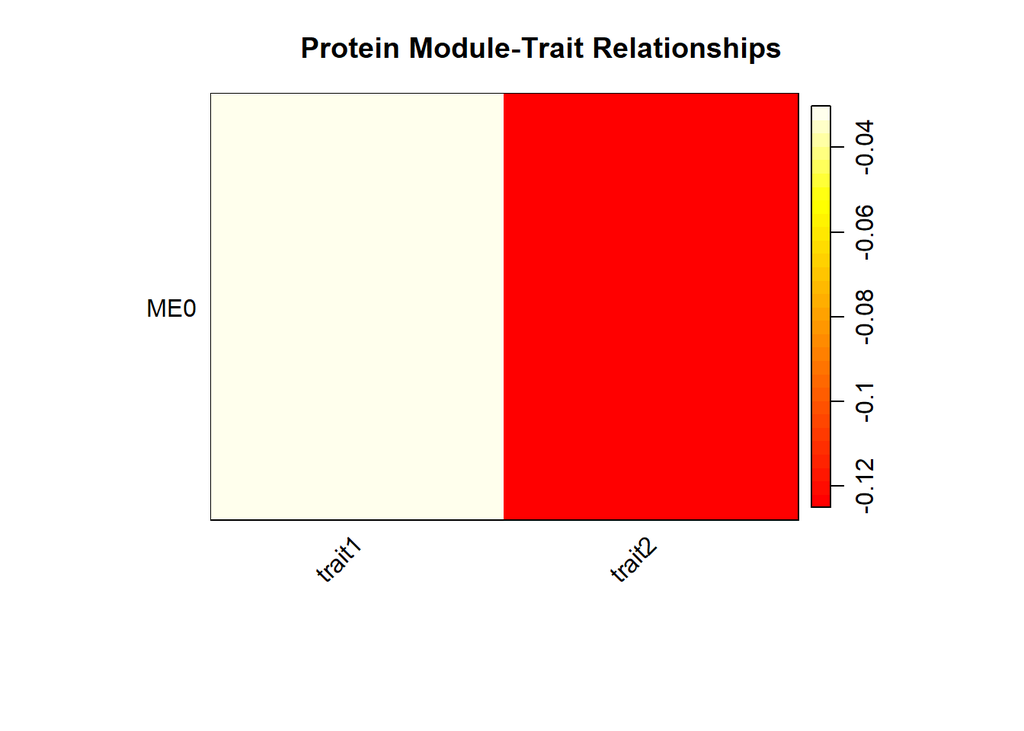

```r
# --- Step 4: Relate Protein Modules to Traits ---
MEs_prot = net_prot$MEs;
moduleTraitCor_prot = cor(MEs_prot, datTraits, use = "p");
moduleTraitPvalue_prot = corPvalueStudent(moduleTraitCor_prot, nSamples);

# Visualize the module-trait relationships using a heatmap
par(mar = c(6, 8.5, 3, 3));
labeledHeatmap(Matrix = moduleTraitCor_prot,
               xLabels = names(datTraits),
               yLabels = names(MEs_prot),
               main = "Protein Module-Trait Relationships")
```

### Downstream Analysis and Interpretation

The output of a WGCNA analysis is the starting point for further biological inquiry. Key downstream steps include:

Identifying Hub Members: Genes or proteins with the highest kME values within significant modules are considered hubs.

Functional Enrichment Analysis: Use tools like Gene Ontology, KEGG, Reactome, or STRING-DB (for proteins) to understand what a module is “doing”.

Network Visualization: Export the network to software like Cytoscape to explore connections and identify hubs visually.

## Conclusion

Weighted Co-expression Network Analysis provides a powerful, systems-level approach to analyzing complex high-dimensional omics data. By reducing complexity from thousands of individual features to a few dozen modules and linking these modules to phenotypes, WGCNA bridges the gap between molecular data and observable biology, making it an indispensable tool for researchers.